# COVID-19 US Data Analysis

2024-03-05

## Introduction

This report summarizes and analyzes COVID-19 case/death data in the US using the Johns Hopkins repository [available here](https://github.com/CSSEGISandData/COVID-19). The main goal of the study will be to characterize the impact of COVID-19 across the various sates and to model the progression of the disease across each state. The main question I would like to answer is if the same model predicting deaths from cases can be applied to all states. To do this, I will use the most impacted state to develop a linear model to calculate number of deaths from number of cases. I will then apply this model to all other states and see how well it works.

## Description of data

The data used is both case and death data from the US as time-series data. There are several geographical identifier columns in each csv that describe county, state/province, and longitude/latitude. The data columns are labeled by date and contain an aggregate number of cases and deaths respectively for each dataset. The data schema is identical between the two csv input files. The data can be accessed at the links used in the “Import data” code cell.

#### Import data.

The data needs to be cleaned up and organized for my intended analysis. For this, I filter out all columns for specific geographic details and aggregate by state/province. This way I can focus my analysis on state-level metrics.

```r
# Loading
deaths <- read.csv("https://raw.githubusercontent.com/CSSEGISandData/COVID-19/master/csse_covid_19_data/csse_covid_19_time_series/time_series_covid19_deaths_US.csv")
confirmed <- read.csv("https://raw.githubusercontent.com/CSSEGISandData/COVID-19/master/csse_covid_19_data/csse_covid_19_time_series/time_series_covid19_confirmed_US.csv")

# I am only interested in US State data for this analysis, so I'll omit territories etc
deaths <- deaths %>%
  filter(Province_State != "Diamond Princess", Province_State != "Grand Princess", Province_State != "American Samoa", Province_State != "District of Columbia", Province_State != "Guam", Province_State != "Northern Mariana Islands", Province_State != "Puerto Rico", Province_State != "Virgin Islands")

confirmed <- confirmed %>%
  filter(Province_State != "Diamond Princess", Province_State != "Grand Princess", Province_State != "American Samoa", Province_State != "District of Columbia", Province_State != "Guam", Province_State != "Northern Mariana Islands", Province_State != "Puerto Rico", Province_State != "Virgin Islands")

# Don't care about columns for geographic codes/coordinates
numeric_columns_deaths <- deaths[, !(names(deaths) %in% c('UID', 'iso2', 'iso3', 'code3', 'FIPS', 'Admin2', 'Country_Region', 'Lat', 'Long_', 'Combined_Key', 'Population'))]
numeric_columns_confirmed <- confirmed[, !(names(confirmed) %in% c('UID', 'iso2', 'iso3', 'code3', 'FIPS', 'Admin2', 'Country_Region', 'Lat', 'Long_', 'Combined_Key'))]

# Want to aggregate by state as I am not interested in stratifying by county
aggregate_deaths_numeric <- aggregate(. ~ Province_State, data = numeric_columns_deaths, FUN = sum, na.rm = TRUE)
aggregate_confirmed_numeric <- aggregate(. ~ Province_State, data = numeric_columns_confirmed, FUN = sum, na.rm = TRUE)
```

#### Visualizations

##### Visualizing total impact of COVID-19 for each state for both deaths and cases.

This will help us understand the overall impact of COVID-19 on each US state/territory

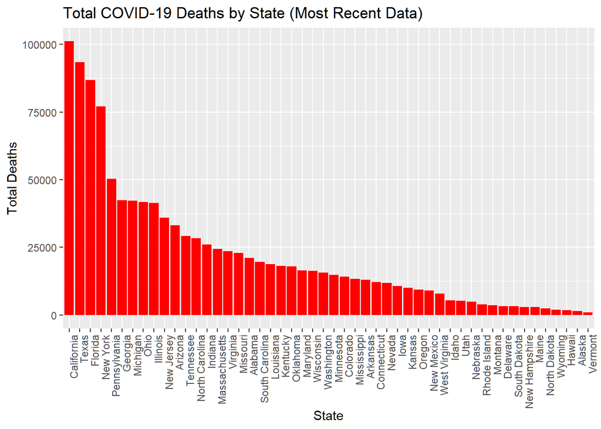

```r
# selecting the last column for deaths and confirmed cases
# The last column has the most recent date
last_column_deaths <- tail(names(aggregate_deaths_numeric), 1)
last_column_confirmed <- tail(names(aggregate_confirmed_numeric), 1)

# total deaths by state
ggplot(aggregate_deaths_numeric, aes_string(x = "reorder(Province_State, -get(last_column_deaths))", y = last_column_deaths)) +
  geom_bar(stat = "identity", fill = "red") +
  theme(axis.text.x = element_text(angle = 90, hjust = 1)) +
  labs(title = "Total COVID-19 Deaths by State (Most Recent Data)", x = "State", y = "Total Deaths")
```

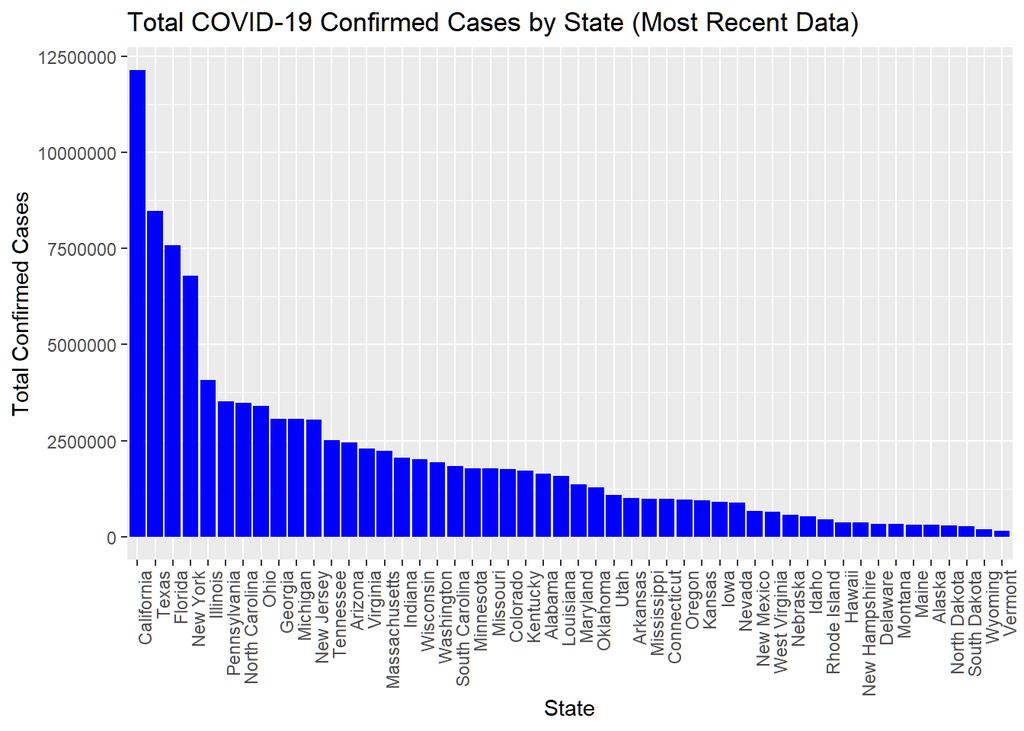

```r
# total confirmed cases by state
ggplot(aggregate_confirmed_numeric, aes_string(x = "reorder(Province_State, -get(last_column_confirmed))", y = last_column_confirmed)) +
  geom_bar(stat = "identity", fill = "blue") +
  theme(axis.text.x = element_text(angle = 90, hjust = 1)) +
  labs(title = "Total COVID-19 Confirmed Cases by State (Most Recent Data)", x = "State", y = "Total Confirmed Cases")
```

##### Visualizing impact to most affected state (California).

Here I want to examine the data to see if I can visually identify any sort of trend I can use to inform the model I choose to develop to explain the data.

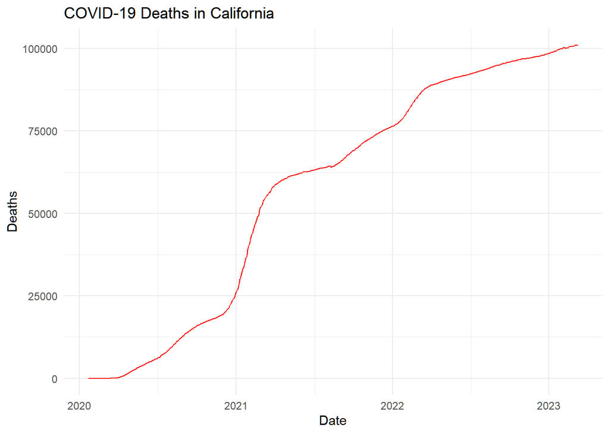

```r
# Need to fix datetime formatting in the columns because it is super unusual
prepared_data <- function(data, value_name) {
  data %>%
    filter(Province_State == "California") %>%
    select(-Province_State) %>%
    pivot_longer(cols = everything(), names_to = "Date", values_to = value_name) %>%
    mutate(Date = sub("X", "", Date),  # Remove 'X' prefix
           Date = as.Date(Date, format = "%m.%d.%y"))  # Convert string to Date
}

# Prepare deaths and confirmed cases data
deaths_ca <- prepared_data(aggregate_deaths_numeric, "Deaths")
confirmed_ca <- prepared_data(aggregate_confirmed_numeric, "Cases")

# Plotting deaths
ggplot(deaths_ca, aes(x = Date, y = Deaths)) +
  geom_line(color = "red") +
  labs(title = "COVID-19 Deaths in California", x = "Date", y = "Deaths") +
  theme_minimal()
```

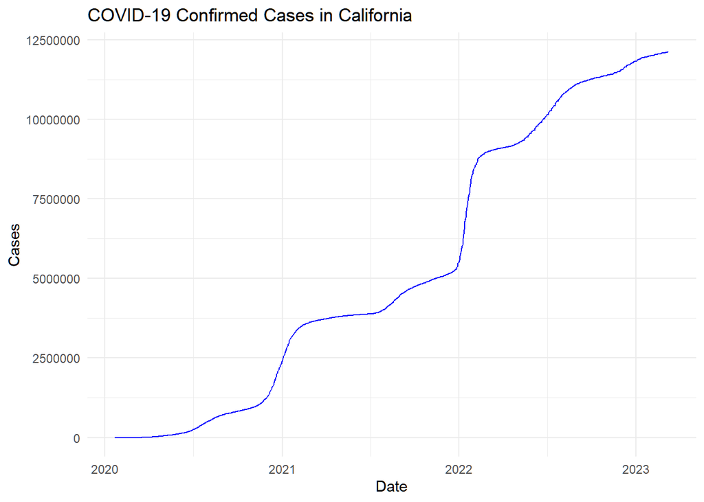

```r
# Plotting confirmed cases
ggplot(confirmed_ca, aes(x = Date, y = Cases)) +
  geom_line(color = "blue") +
  labs(title = "COVID-19 Confirmed Cases in California", x = "Date", y = "Cases") +
  theme_minimal()
```

#### Modeling

Both deaths and cases seem to increase at similar rates, so let’s see if we can model deaths as a function of cases. As they seem to increase co linearly, I will use a linear regression model.

```r
ca_data <- merge(deaths_ca, confirmed_ca, by = "Date")

# Fitting deaths as a function of Cases
model <- lm(Deaths ~ Cases, data = ca_data)

# Summarize the model
summary(model)
```

```
##
## Call:
## lm(formula = Deaths ~ Cases, data = ca_data)
##
## Residuals:
##    Min     1Q Median     3Q    Max
## -14562  -9072  -4625  14038  19911
##
## Coefficients:
##              Estimate Std. Error t value Pr(>|t|)
## (Intercept) 1.456e+04  5.446e+02   26.73   <2e-16 ***
## Cases       7.922e-03  7.935e-05   99.83   <2e-16 ***
## ---
## Signif. codes:  0 '***' 0.001 '**' 0.01 '*' 0.05 '.' 0.1 ' ' 1
##
## Residual standard error: 11390 on 1141 degrees of freedom
## Multiple R-squared:  0.8973, Adjusted R-squared:  0.8972
## F-statistic:  9967 on 1 and 1141 DF,  p-value: < 2.2e-16
```

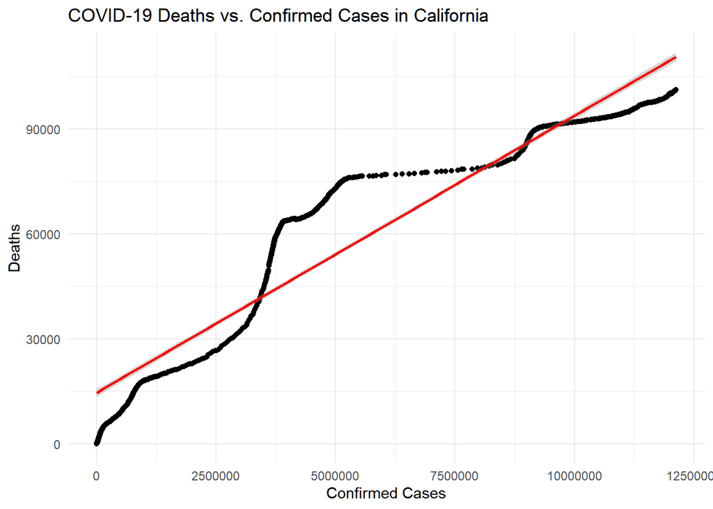

```r
# Plotting the relationship along with the regression line
ggplot(ca_data, aes(x = Cases, y = Deaths)) +
  geom_point() +
  geom_smooth(method = "lm", col = "red") +
  labs(title = "COVID-19 Deaths vs. Confirmed Cases in California",
       x = "Confirmed Cases", y = "Deaths") +
  theme_minimal()
```

These results show a quite strong R^2 value of 0.8973 which means that 89.73% of the variance in death counts can be explained by using number of confirmed cases as a predictor. Given the generally high prediction, this seems to be a good model and we can carry on applying it to the other states. To put our linear model into plain text, we can model our deaths resulting from cases using the equation (number of deaths)=0.007922*(number of cases)+14560

To evaluate efficacy of the model, I will use Root Mean Squared Error (RMSE). This basically provides a measure of the difference between the value predicted by the linear model and actual values.

```r
# Join data to easily access case and death data for each state.
# The output of this join has row names as the state name, all death time series columns, then all case time series columns.
state_data <- inner_join(aggregate_deaths_numeric, aggregate_confirmed_numeric, by = "Province_State", suffix = c("_deaths", "_cases"))

# Calculate the index of the last death column to find the most recent death total
# because deaths and cases have the same number of columns, we can just find the middle column
last_death_column_index <- ncol(state_data) / 2

# Calculate the index of the last case column
# This is just the last column
last_case_column_index <- ncol(state_data)

state_data <- state_data %>%
  mutate(
    most_recent_deaths = .[[last_death_column_index]],  # most recent death count
    most_recent_cases = .[[last_case_column_index]],  # most recent case count
    predicted_deaths = 0.007922 * most_recent_cases + 14560  # Applies the linear model
  ) %>%
  select(Province_State, most_recent_deaths, predicted_deaths)  # Keeps only relevant columns

# Calculate RMSE for each state
calc_rmse <- function(actual, predicted) {
  sqrt(mean((predicted - actual)^2))
}

state_data <- state_data %>%
  rowwise() %>%
  mutate(rmse = calc_rmse(most_recent_deaths, predicted_deaths)) %>%
  ungroup()

# View the RMSE values for each state
print(state_data, n = Inf)
```

```
## # A tibble: 50 × 4
##    Province_State most_recent_deaths predicted_deaths   rmse
##    <chr>                       <int>            <dbl>  <dbl>
##  1 Alabama                     21032           27588.  6556.
##  2 Alaska                       1486           16997. 15511.
##  3 Arizona                     33102           33918.   816.
##  4 Arkansas                    13015           22537.  9522.
##  5 California                 100954          110651.  9697.
##  6 Colorado                    14181           28538. 14357.
##  7 Connecticut                 12196           22297. 10101.
##  8 Delaware                     3324           17181. 13857.
##  9 Florida                     86850           74566. 12284.
## 10 Georgia                     42489           38866.  3623.
## 11 Hawaii                       1841           17575. 15734.
## 12 Idaho                        5416           18688. 13272.
```

[output cut: 38 more lines]